# Machine Learning Project - Kaggle Heart Failure

# HEART FAILURE PREDICTION

This project involves using heart failure data from different patients to create a machine learning model which can be used for predicting whether a patient is likely to have a fatal heart failure event. There are several steps taken in this project. Step 1 involves loading, visualising and transforming the data, step 2 involves splitting the data into a training and test set which will be used during the modeling steps. Step 3 involves trying out different models and comparing the accuracy, ROC plot and AUC. Step 4 is short listing the best models which will then be further tuned to improve the performance (hyperparameters), step 5 will involve feature engineering to attempt to further improve performance of the models. A final best model will be chosen.

## STEP 1: Adding required libraries, loading dataset, transforming and visualling data -

```r
library(caret)
library(tidyverse)
library(corrplot)
library(ggplot2)
library(pROC)
library(ROCR)
library(xgboost)
library(rattle)
library(dplyr)
```

The required libraries are imported.

```r
file_path <- "~/Desktop/Graduate Life/Machine Learning/Kaggle Datasets"
raw_dataset <- read.csv(paste(file_path,"heart_failure_clinical_records_dataset.csv",sep="/"), header=TRUE) #Load CSV
glimpse(raw_dataset)
```

```
Rows: 299
Columns: 13
$ age                      <dbl> 75, 55, 65, 50, 65, 90, 75, 60, 65, 80, 75, 62, 45, 50, 49,…
$ anaemia                  <int> 0, 0, 0, 1, 1, 1, 1, 1, 0, 1, 1, 0, 1, 1, 1, 1, 1, 0, 1, 1,…
$ creatinine_phosphokinase <int> 582, 7861, 146, 111, 160, 47, 246, 315, 157, 123, 81, 231, …
$ diabetes                 <int> 0, 0, 0, 0, 1, 0, 0, 1, 0, 0, 0, 0, 0, 0, 0, 0, 0, 0, 0, 1,…
$ ejection_fraction        <int> 20, 38, 20, 20, 20, 40, 15, 60, 65, 35, 38, 25, 30, 38, 30,…
$ high_blood_pressure      <int> 1, 0, 0, 0, 0, 1, 0, 0, 0, 1, 1, 1, 0, 1, 1, 0, 0, 0, 1, 0,…
$ platelets                <dbl> 265000, 263358, 162000, 210000, 327000, 204000, 127000, 454…
$ serum_creatinine         <dbl> 1.90, 1.10, 1.30, 1.90, 2.70, 2.10, 1.20, 1.10, 1.50, 9.40,…
$ serum_sodium             <int> 130, 136, 129, 137, 116, 132, 137, 131, 138, 133, 131, 140,…
$ sex                      <int> 1, 1, 1, 1, 0, 1, 1, 1, 0, 1, 1, 1, 1, 1, 0, 1, 1, 1, 0, 0,…
$ smoking                  <int> 0, 0, 1, 0, 0, 1, 0, 1, 0, 1, 1, 1, 0, 0, 0, 0, 0, 0, 0, 0,…
$ time                     <int> 4, 6, 7, 7, 8, 8, 10, 10, 10, 10, 10, 10, 11, 11, 12, 13, 1…
$ DEATH_EVENT              <int> 1, 1, 1, 1, 1, 1, 1, 1, 1, 1, 1, 1, 1, 1, 0, 1, 1, 1, 1, 1,…
```

The kaggle dataset for the heart failure clinical records is the loaded and a glimpse of the dataset is presented. Here we can see that there are binary features which are currently of the wrong datatype (should be factors). This is fixed by mutating the columns. There are also 299 patient data rows made up of 13 columns (12 feature variables and 1 response variable).

```r
dataset <- raw_dataset %>%
  mutate(anaemia = if_else(anaemia==1,"YES","NO"),
         diabetes = if_else(diabetes==1,"YES","NO"),
         high_blood_pressure = if_else(high_blood_pressure==1,"YES","NO"),
         sex = if_else(sex==1,"MALE","FEMALE"),
         smoking = if_else(smoking==1,"YES","NO"),
         DEATH_EVENT = if_else(DEATH_EVENT==1,"YES","NO"),
         age = as.integer(age),
         platelets = as.integer(platelets)
  ) %>%
  mutate_if(is.character,as.factor) %>%
  dplyr::select(DEATH_EVENT,anaemia,diabetes,high_blood_pressure,sex,smoking,everything())
```

The features ‘anaemia’, ‘diabetes’, high_blood_pressure’, ‘sex’, ‘smoking’, ‘DEATH_EVENT’ are converted to factors where 1 = ‘YES’ and 0 = ‘NO’. ‘Sex’ is also converted to a factor with 1 = ‘MALE’ and 0 = ‘FEMALE’. Finally ‘age’ and ‘platelets’ are converted to intergers as they are currently doubles.

We then glimpse the transformed dataset to ensure this has worked and then have a look at the first 6 rows of the dataset.

```r
glimpse(dataset)
```

```
Rows: 299
Columns: 13
$ DEATH_EVENT              <fct> YES, YES, YES, YES, YES, YES, YES, YES, YES, YES, YES, YES,…
$ anaemia                  <fct> NO, NO, NO, YES, YES, YES, YES, YES, NO, YES, YES, NO, YES,…
$ diabetes                 <fct> NO, NO, NO, NO, YES, NO, NO, YES, NO, NO, NO, NO, NO, NO, N…
$ high_blood_pressure      <fct> YES, NO, NO, NO, NO, YES, NO, NO, NO, YES, YES, YES, NO, YE…
$ sex                      <fct> MALE, MALE, MALE, MALE, FEMALE, MALE, MALE, MALE, FEMALE, M…
$ smoking                  <fct> NO, NO, YES, NO, NO, YES, NO, YES, NO, YES, YES, YES, NO, N…
$ age                      <int> 75, 55, 65, 50, 65, 90, 75, 60, 65, 80, 75, 62, 45, 50, 49,…
$ creatinine_phosphokinase <int> 582, 7861, 146, 111, 160, 47, 246, 315, 157, 123, 81, 231, …
$ ejection_fraction        <int> 20, 38, 20, 20, 20, 40, 15, 60, 65, 35, 38, 25, 30, 38, 30,…
$ platelets                <int> 265000, 263358, 162000, 210000, 327000, 204000, 127000, 454…
$ serum_creatinine         <dbl> 1.90, 1.10, 1.30, 1.90, 2.70, 2.10, 1.20, 1.10, 1.50, 9.40,…
$ serum_sodium             <int> 130, 136, 129, 137, 116, 132, 137, 131, 138, 133, 131, 140,…
$ time                     <int> 4, 6, 7, 7, 8, 8, 10, 10, 10, 10, 10, 10, 11, 11, 12, 13, 1…
```

```r
head(dataset)
```

|  | DEATH_EVENT | anaemia | diabetes | high_blood_pressure | sex | smoking | age | creatinine_phosphokinase | ejection_fraction | platelets | serum_creatinine | serum_sodium | time |
| --- | --- | --- | --- | --- | --- | --- | --- | --- | --- | --- | --- | --- | --- |
| 1 | YES | NO | NO | YES | MALE | NO | 75 | 582 | 20 | 265000 | 1.9 | 130 | 4 |
| 2 | YES | NO | NO | NO | MALE | NO | 55 | 7861 | 38 | 263358 | 1.1 | 136 | 6 |
| 3 | YES | NO | NO | NO | MALE | YES | 65 | 146 | 20 | 162000 | 1.3 | 129 | 7 |
| 4 | YES | YES | NO | NO | MALE | NO | 50 | 111 | 20 | 210000 | 1.9 | 137 | 7 |
| 5 | YES | YES | YES | NO | FEMALE | NO | 65 | 160 | 20 | 327000 | 2.7 | 116 | 8 |
| 6 | YES | YES | NO | YES | MALE | YES | 90 | 47 | 40 | 204000 | 2.1 | 132 | 8 |

We can take a look at the percentage breakdown of those who have had a fatal heart failure vs those patients who have not. Here we see approx. 32% of patients suffered a fatal event, whilst 68% did not.

```r
percentage <- prop.table(table(dataset$DEATH_EVENT)) * 100
cbind(freq=table(dataset$DEATH_EVENT), percentage=percentage)
```

```
    freq percentage
NO   203   67.89298
YES   96   32.10702
```

A correlation plot of the non-categorical variables shows there is not much correlation between the different features.

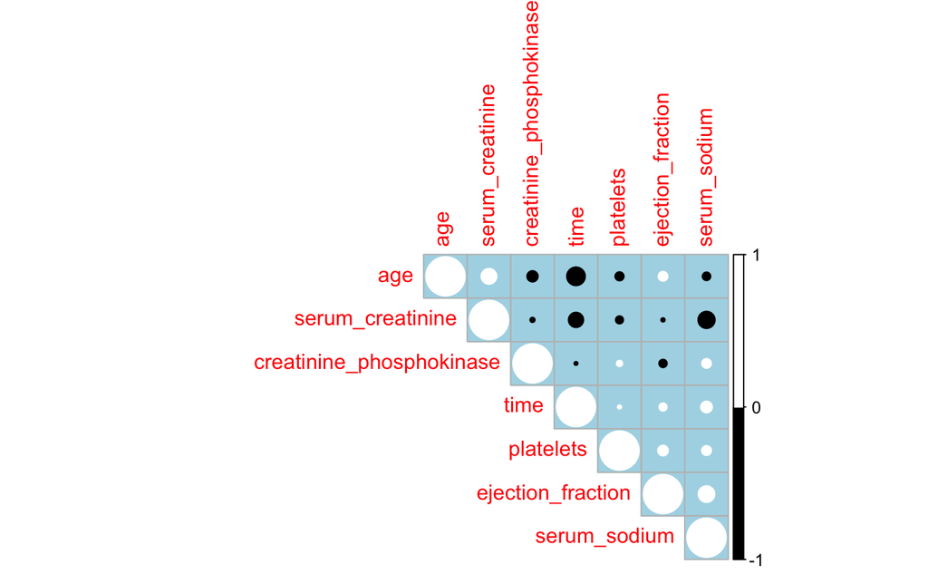

```r
corr_data <- cor(dataset[7:13])
corrplot(corr_data, order="hclust", col=c("black", "white"), bg="lightblue", type="upper")
```

This can further seen in the plots below which show that there is little correlation between the different continuous numerical features.

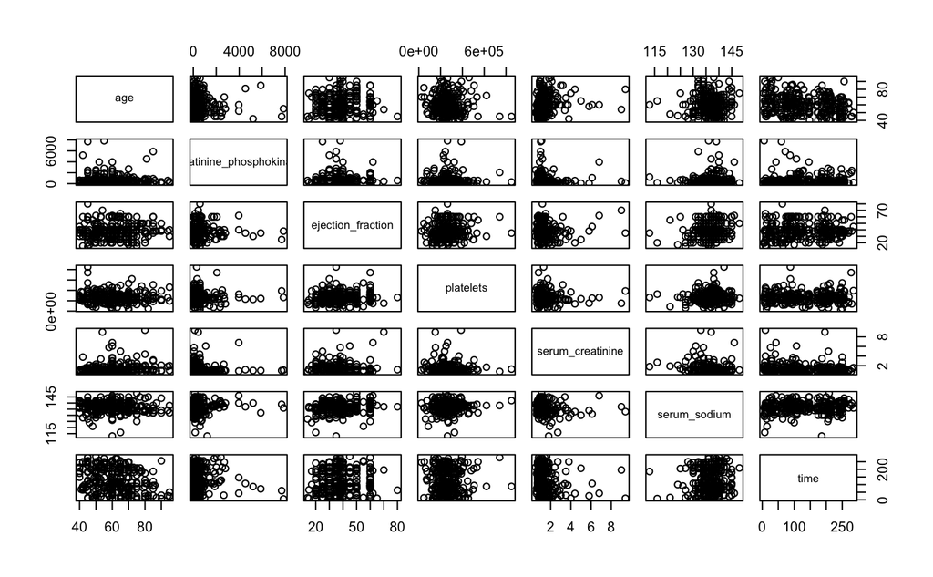

```r
plot(dataset[7:13])
```

## STEP 2: splitting dataset into training and test sets.

The dataset is then split into a training sample and a test sample. The training:test split will be 80:20. The training data will be exclusively used to train the different models (using K Fold Cross Validation) and the test data is used exclusively for measuring the performance of the models.

```r
set.seed(1995)
training_samples <- createDataPartition(dataset$DEATH_EVENT, p=0.80, list=FALSE)
train_data <- dataset[training_samples,]
test_data <- dataset[-training_samples,]
```

## STEP 3: Training the different models

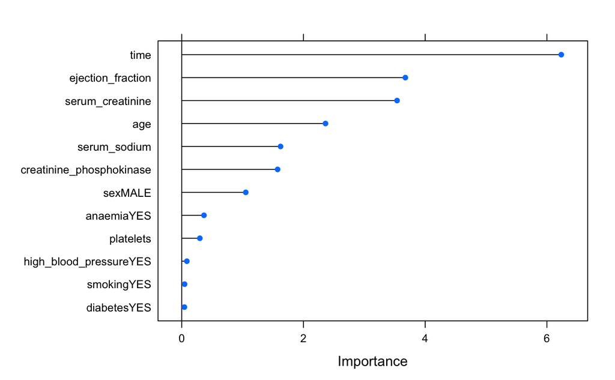

```r
set.seed(692)
train_control <- trainControl(method="repeatedcv", number=10)
log_model <- train(DEATH_EVENT~., data=train_data, trControl=train_control, method="glm", family="binomial")
importance <- varImp(log_model, scale=FALSE)
plot(importance)
```

Logistic Regression:

```r
set.seed(692)
train_control <- trainControl(method="repeatedcv", number=10)
log_model <- train(DEATH_EVENT~ age + ejection_fraction + serum_creatinine + time,
                   data=train_data, trControl=train_control, method="glm", family="binomial")
log_pred <- predict(log_model,newdata = test_data)
```

K Nearest Neighbors:

```r
set.seed(200)
train_control <- trainControl(method="repeatedcv", number=10)
knn_model <- train(DEATH_EVENT ~ age + ejection_fraction + serum_creatinine + time, data = train_data, method = "knn", trControl=train_control, preProcess = c("center", "scale"), tuneLength = 10)
knn_pred <- predict(knn_model, newdata = test_data)
```

Support Vector Machine:

```r
set.seed(723)
train_control <- trainControl(method="repeatedcv", number=10, classProbs =  TRUE)
svm_model <- train(DEATH_EVENT ~age + ejection_fraction + serum_creatinine + time, data = train_data, method = "svmLinear", trControl = train_control, preProcess = c("center","scale"))
svm_pred <- predict(svm_model, newdata = test_data)
```

SVM using Non-Linear Kernel

```r
set.seed(139)
train_control <- trainControl(method="repeatedcv", number=10, classProbs =  TRUE)
non_svm_model <- train(DEATH_EVENT~ age + ejection_fraction + serum_creatinine + time, data=train_data, trControl=train_control, method="svmRadial", preProcess=c("center", "scale"), tunelength=10)
non_svm_pred <- predict(non_svm_model, newdata = test_data)
```

Decision Tree:

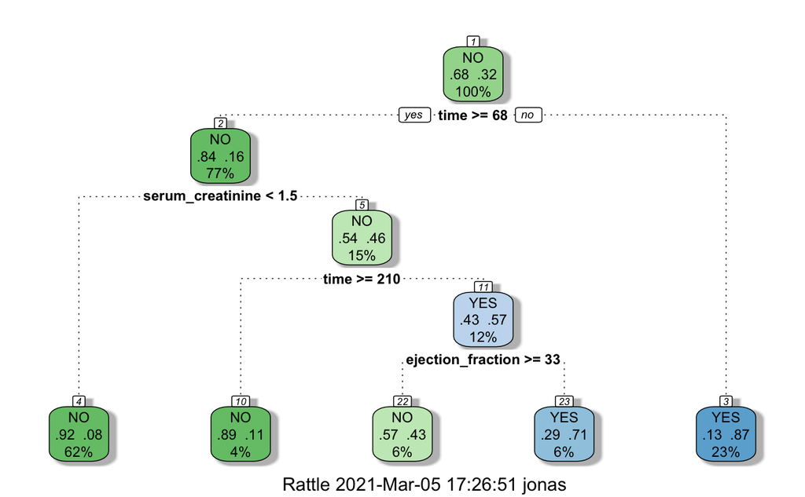

```r
set.seed(823)
train_control <- trainControl(method="cv", number=10)
tree_model <- train(DEATH_EVENT~age + ejection_fraction + serum_creatinine + time, data=train_data, trControl=train_control, method="rpart")
fancyRpartPlot(tree_model$finalModel)
```

```r
tree_pred <- predict(tree_model, newdata = test_data)
```

Random Forest Ensemble:

```r
set.seed(536)
train_control <- trainControl(method="repeatedcv", number=10)
rf_model <- train(DEATH_EVENT~., data=train_data, trControl=train_control, method="rf")
rf_pred <- predict(rf_model,newdata = test_data)
```

Stochastic Gradient Boosting:

```r
set.seed(629)
train_control <- trainControl(method="repeatedcv", number=10)
gbm_model <- train(DEATH_EVENT~age + ejection_fraction + serum_creatinine + time, data=train_data, trControl=train_control, method="gbm", verbose=0)
gbm_pred <- predict(gbm_model, newdata = test_data)
```

Extreme Gradient Boosting:

```r
set.seed(467)
train_control <- trainControl(method="repeatedcv", number=10)
xgb_model <- train(DEATH_EVENT~., data=train_data, trControl=train_control, method="xgbTree")
xgb_pred <- predict(xgb_model,newdata = test_data)
```

Neural Networks:

```r
set.seed(888)
train_control <- trainControl(method = 'repeatedcv', number = 10, classProbs = TRUE, verboseIter = FALSE, summaryFunction = twoClassSummary, preProcOptions = list(thresh = 0.75, ICAcomp = 3, k = 5))
nn_model <- train(DEATH_EVENT~anaemia + age + ejection_fraction + serum_creatinine + time, data = train_data, method = 'nnet', preProcess = c('center', 'scale'), trControl = train_control, metric = "ROC", trace=FALSE)
nn_pred <- predict(nn_model, newdata = test_data)
```

## STEP 4: Performance Metrics

To compare the performance of the different models, in order to select a shortlist of the best models, accuracy, sensitivity, specificity and AUC are used to compare.

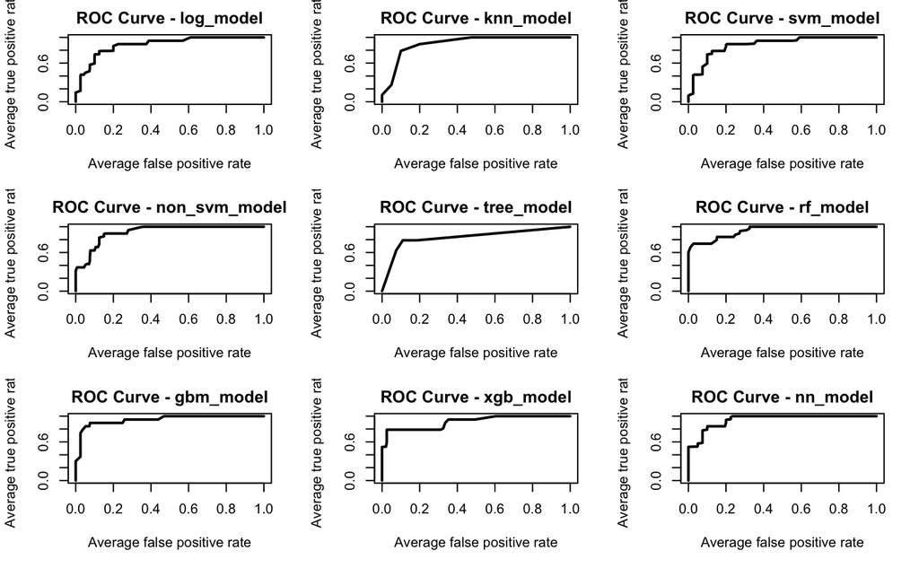

```r
roc_auc_metrics <- function(model, model_name){
  model_pred <- predict(model,newdata = test_data, type="prob")
  pred <- prediction(model_pred[,2], test_data$DEATH_EVENT)
  perf <- performance(pred, measure = "tpr", x.measure = "fpr") #tpr - True Positive Rate/Sensitivity
  plot(perf,avg= "threshold", lwd= 2, main= paste("ROC Curve -",model_name,sep = " "))
  #auc(test_data$DEATH_EVENT,model_pred[,2])
  }

models_list <- dplyr::lst(log_model,knn_model,svm_model,non_svm_model,tree_model,rf_model,gbm_model,xgb_model, nn_model)
par(mfrow=c(3,3))
for(model in names(models_list)){
  roc_auc_metrics(models_list[[model]],model)
}
```

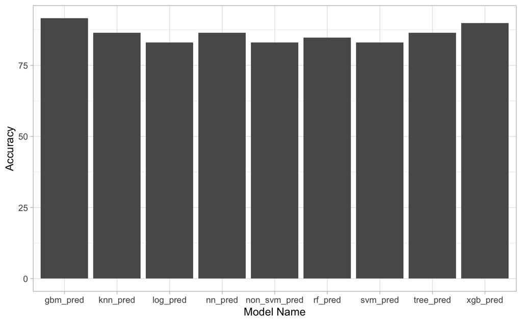